# Clustering Analysis for Namjoshi et al. 2017

Sanjeev V Namjoshi

February 23rd, 2017

This file contains all the data used for clustering the filtered count data.

### Load packages

```r
library(ggplot2)
library(reshape2)
library(magrittr)
library(RDAVIDWebService)
library(org.Mm.eg.db)
library(gridExtra)
library(xlsx)
library(factoextra)
library(Ckmeans.1d.dp)
library(dplyr)
library(gdata)
library(amap)
```

### Load functions

The `functionalAnnotationChart()` function a list of genes, and ontology (term), and an output file name. It returns the Functional Annotation Chart from DAVID.

```r
functionalAnnotationChart <- function(genes, term, filename) {

  require(RDAVIDWebService)
  require(org.Mm.eg.db)

  david <- DAVIDWebService$new(email = "snamjoshi87@utexas.edu", url = "https://david.ncifcrf.gov/webservice/services/DAVIDWebService.DAVIDWebServiceHttpSoap12Endpoint/")
  egenes <- select(org.Mm.eg.db, genes, "ENTREZID", "SYMBOL")[,2]

  chart <- addList(david, egenes,
                   idType = "ENTREZ_GENE_ID",
                   listName = "Functional Annotation Chart",
                   listType = "Gene")

  setAnnotationCategories(david, term)
  getFunctionalAnnotationChartFile(david, fileName = filename)

  return(paste("Ouput DAVID analysis file:", filename))
}
```

The `uniqueFilteredGoTerms()` function a list of downregulated genes and a list of upregulated genes from DAVID results, and a desired PValue and FDR cutoff. It first applies these cutoffs to both data sets. Then, it finds the unique GO terms between the remaining terms.

```r
uniqueFilteredGoTerms <- function(downfileName, upfileName, PValue, FDR) {
  downBP <- read.table(downfileName, sep = "\t", header = TRUE, stringsAsFactors = FALSE, quote = "")
  downBP <- downBP[ ,c("Term", "PValue", "FDR")]
  downBP <- downBP[downBP$PValue < PValue | downBP$FDR < FDR, ]

  upBP <- read.table(upfileName, sep = "\t", header = TRUE, stringsAsFactors = FALSE, quote = "")
  upBP <- upBP[ , c("Term", "PValue", "FDR")]
  upBP <- upBP[upBP$PValue < PValue | upBP$FDR < FDR, ]

  sharedBP <- intersect(downBP$Term, upBP$Term)
  downOnlyBP <- setdiff(downBP$Term, upBP$Term)
  upOnlyBP <- setdiff(upBP$Term, downBP$Term)

  downOnlyTableBP <- downBP[downBP$Term %in% downOnlyBP, c("Term", "PValue", "FDR")]
  upOnlyTableBP <- upBP[upBP$Term %in% upOnlyBP, c("Term", "PValue", "FDR")]

  downOnlyTableBP <- downOnlyTableBP[order(downOnlyTableBP$PValue), "Term"]
  upOnlyTableBP <- upOnlyTableBP[order(upOnlyTableBP$PValue), "Term"]

  return(list(downTable = downOnlyTableBP, upTable = upOnlyTableBP))
}
```

The `simplifyGo()` function takes a DAVID functional annotation chart and creates a similarity matrix for each GO term with every other GO term by using two different similarity metrics: the jaccard cutoff (JC) and overlap coefficient (OC) where $JC = \frac{\left |A \cap B \right |}{\left |A \cup B \right |}$ and $OC = \frac{\left |A \cap B \right |}{Min(\left | A \right |,\left | B \right |)}$. This approach is based off of *[1]*. The similarity metrics are calculated within the subfunction called `similarity()`. These metrics are two different ways of assessing the degree of overlap between two gene lists.

The average score of JC and OC for each set of genes associated with a GO term is computed in a giant similarity matrix for all GO terms. Note that this procedure is very computational intensive. Finally, the matrix is filtered for a similarity cutoff of > 0.5. The function then returns this matrix.

```r
simplifyGo <- function(david_chart) {

  ### Similarity function for overlap coefficient and jaccard cutoff
  similarity <- function(list) {

    A <- list[[1]]
    B <- list[[2]]

    JC <- function(A, B) {
      output <- (intersect(A, B) %>% length()) / (union(A, B) %>% length())
      return(output)
    }

    OC <- function(A, B) {
      output <- (intersect(A, B) %>% length()) / (min(length(A), length(B)))
      return(output)
    }

    similarity <- mean(c(OC(A, B), JC(A, B)))
    return(similarity)
  }

  ### Create similarity matrix
  list1 <- david_chart[ ,"Genes"] %>% strsplit(split  = ",") %>% lapply(FUN = as.numeric)
  list2 <- list1

  computeSimilarity <- Vectorize(function(x, y) {
    vec1 <- list1[[x]]
    vec2 <- list2[[y]]

    similarity(list(vec1, vec2))
  })

  filterMatrix <- outer(1:length(list1), 1:length(list2), computeSimilarity)
  rownames(filterMatrix) <- david_chart[ ,"Term"]
  colnames(filterMatrix) <- david_chart[ ,"Term"]
  filterMatrix[filterMatrix < 0.5] <- 0

  return(filterMatrix)
}
```

The `getDendrogramClusters()` function is used to extract the cluster data from the `hcut()` function.

```r
getDendrogramClusters <- function(hcut_output) {
  clusters <- data.frame(Cluster = hcut_output$cluster %>% unname(),
                         Term = hcut_output$labels)

  labels <- merge(data.frame(Term = labels(hcut_output %>% as.dendrogram()),
                             Order = 1:nrow(clusters)), clusters, "Term")

  output <- labels[order(labels$Order), ]
  return(output)
}
```

The `determineClusterNumbers()` function utilizes the within sum of squares (WSS) to estimate cluster number for hierachical clustering of the GO terms (based on their similarity index). The function returns a plot which is used to approximate the clusters.

```r
determineClusterNumbers <- function(x, n) {
  require(ggplot2)

  wss <- (nrow(x) - 1) * sum(apply(x, 2, var))

  for(i in 2:n) {
    wss[i] <- sum(kmeans(x, centers = i)$withinss)
  }

  wss <- as.data.frame(cbind(wss, clusters = 1:n))

  plot <- ggplot(wss, aes(clusters, wss)) +
    geom_line() +
    geom_point() +
    theme_bw()

  return(plot)
}
```

The `determineClusterNumbers1D()` function operates simarilary to the above function but instead provides WSS for a univariate distribution with K-means.

```r
determineClusterNumbers1D <- function(x, n) {
  require(ggplot2)
  require(Ckmeans.1d.dp)

  wss <- (length(x) - 1) * var(x)

  for(i in 2:n) {
    wss[i] <- sum(Ckmeans.1d.dp(x, i)$withinss)
  }

  wss <- as.data.frame(cbind(wss, clusters = 1:n))

  plot <- ggplot(wss, aes(clusters, wss)) +
    geom_line() +
    geom_point() +
    theme_bw()

  return(plot)
}
```

The `kMeanPlot()` function takes a two column data frame (x) and the number of cluster (n), clusters the data, and graphs it.

```r
require(amap)

colorFunc <- colorRampPalette(c("lightblue", "blue"))

kMeansPlot <- function(x, n) {
  clustDat <- as.matrix(x)
  clustDat[is.na(clustDat)] <- 0
  kClust <- Kmeans(clustDat, centers = n, method = "pearson", iter.max = 50)

  clustDat <- as.data.frame(cbind(clustDat, clusters = kClust$cluster))
  clustDat$clusters <- as.factor(clustDat$clusters)
  centers <- as.data.frame(kClust$centers)

  clustPlot <- ggplot(clustDat, aes(RO, RO_RAP, color = clusters, fill = clusters)) +
    geom_point() +
    geom_vline(xintercept = 0, color = "black") +
    geom_hline(yintercept = 0, color = "black") +
    xlab("Ro Fold Change") +
    ylab("Ro+Rapamycin Fold Change") +
    xlim(-1.5,1.5) +
    ylim(-1.5,1.5) +
    ggtitle("K Means Clustering for Ro or Ro+Rapa Fold Changes") +
    theme_bw()

  clustPlot
}
```

### Load data and filter

```r
fc <- read.csv("finalData.csv", header = TRUE, stringsAsFactors = FALSE)
row.names(fc) <- fc$Row.names
fc[ ,1] <- NULL
fc <- fc[ ,c("logFC.x", "logFC.y")]
names(fc) <- c("RO", "RO_RAP")

counts <- read.csv("finalCountData.csv", header = TRUE, stringsAsFactors = FALSE, row.names = 1)
countsAvg <- data.frame(row.names = row.names(counts),
                        SAL_WT = rowMeans(counts[ ,1:3]),
                        RO_WT = rowMeans(counts[ ,7:9]),
                        RO_RAP_WT = rowMeans(counts[ ,11:13]))
countsAvg.log <- apply(countsAvg, 2, log2) %>% as.data.frame()

### Here we apply a fold-change filter
roDownGenes <- fc[fc$RO < quantile(fc$RO, 0.25), ]
roUpGenes <- fc[fc$RO > quantile(fc$RO, 0.75), ]

roRapDownGenes <- fc[fc$RO_RAP < quantile(fc$RO_RAP, 0.25), ]
roRapUpGenes <- fc[fc$RO_RAP > quantile(fc$RO_RAP, 0.75), ]
```

### Differential binding

This graph is just to illustrate the differential binding effects seen in different fold-change conditions.

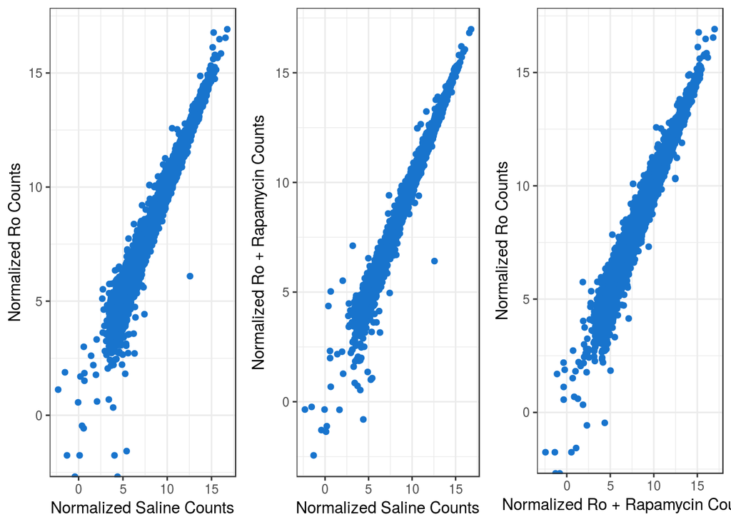

```r
p1 <-
  ggplot(countsAvg.log, aes(x = SAL_WT, y = RO_WT)) +
  geom_point(color = "dodgerblue3") +
  xlab("Normalized Saline Counts") +
  ylab("Normalized Ro Counts") +
  theme_bw()

p2 <-
  ggplot(countsAvg.log, aes(x = SAL_WT, y = RO_RAP_WT)) +
  geom_point(color = "dodgerblue3") +
  xlab("Normalized Saline Counts") +
  ylab("Normalized Ro + Rapamycin Counts") +
  theme_bw()

p3 <-
  ggplot(countsAvg.log, aes(x = RO_RAP_WT, y = RO_WT)) +
  geom_point(color = "dodgerblue3") +
  xlab("Normalized Ro + Rapamycin Counts") +
  ylab("Normalized Ro Counts") +
  theme_bw()

grid.arrange(p1, p2, p3,
             ncol = 3,
             nrow = 1)
```

### Unique GO clustering by fold-change group

Code to generate DAVID Functional Annotation Charts for Ro and RoRap. For all DAVID charts, we used a p-value cutoff of 0.001 and FDR cutoff of 0.05. The strategy here is to use the GO cutoffs from early to cluster on the basis of similarity. This will group like GO-terms together in a branch on the dendrogram. This unbiased approach allows us to give our own names manually to each major cluster family. Then, we can take the average p-value within each branch, the average number of genes per GO term, and plot this with **ggplot2**. To determine cluster number, the within sum of squares (WSS) is graphed for *n* clusters. The chosen cluster number attempts ot minimze the WSS of squares by visually seeing where the overall shape of the plot begins to flatten out on the y-axis.

```r
### Query DAVID for Ro and get unique GO terms
functionalAnnotationChart(roDownGenes,
                          term = "GOTERM_BP_ALL",
                          filename = "david_ro_down_1000_biological_process.txt")

functionalAnnotationChart(roUpGenes,
                          term = "GOTERM_BP_ALL",
                          filename = "david_ro_up_1000_biological_process.txt")

uniqueBpRo <- uniqueFilteredGoTerms(downfileName = "david_ro_down_1000_biological_process.txt",
                                    upfileName = "david_ro_up_1000_biological_process.txt",
                                    PValue = 0.001,
                                    FDR = 0.05)

### Query DAVID for Ro+Rap and get unique GO terms
functionalAnnotationChart(roRapDownGenes,
                          term = "GOTERM_BP_ALL",
                          filename = "david_roRap_down_1000_biological_process.txt")

functionalAnnotationChart(roRapUpGenes,
                          term = "GOTERM_BP_ALL",
                          filename = "david_roRap_up_1000_biological_process.txt")

uniqueBpRoRap <- uniqueFilteredGoTerms(downfileName = "david_roRap_down_1000_biological_process.txt",
                                       upfileName = "david_roRap_up_1000_biological_process.txt",
                                       PValue = 0.001,
                                       FDR = 0.05)

### Query DAVID for candidate depression genes
dep <- read.csv("depression_gene_candidates.csv", header = FALSE, stringsAsFactors = FALSE)$V1

dep <- sapply(dep, function(x) {
  y <- tolower(x)
  y <- paste0(toupper(substr(y, 1, 1)), substr(y, 2, nchar(y)))
  return(y)
  })

names(dep) <- NULL

functionalAnnotationChart(dep,
                          term = "GOTERM_BP_ALL",
                          filename = "david_depression_1000_biological_process.txt")

### Query DAVID for consensus FMRP genes
BD <- read.xlsx("consensus_FMRP.xlsx", sheetIndex = 4, header = FALSE, startRow = 2, stringsAsFactors = FALSE)$X1

BD <- sapply(BD, function(x) {
  y <- tolower(x)
  y <- paste0(toupper(substr(y, 1, 1)), substr(y, 2, nchar(y)))
  return(y)
})

names(BD) <- NULL

functionalAnnotationChart(BD,
                          term = "GOTERM_BP_ALL",
                          filename = "david_BD_1000_biological_process.txt")
```

#### Ro top GO chart

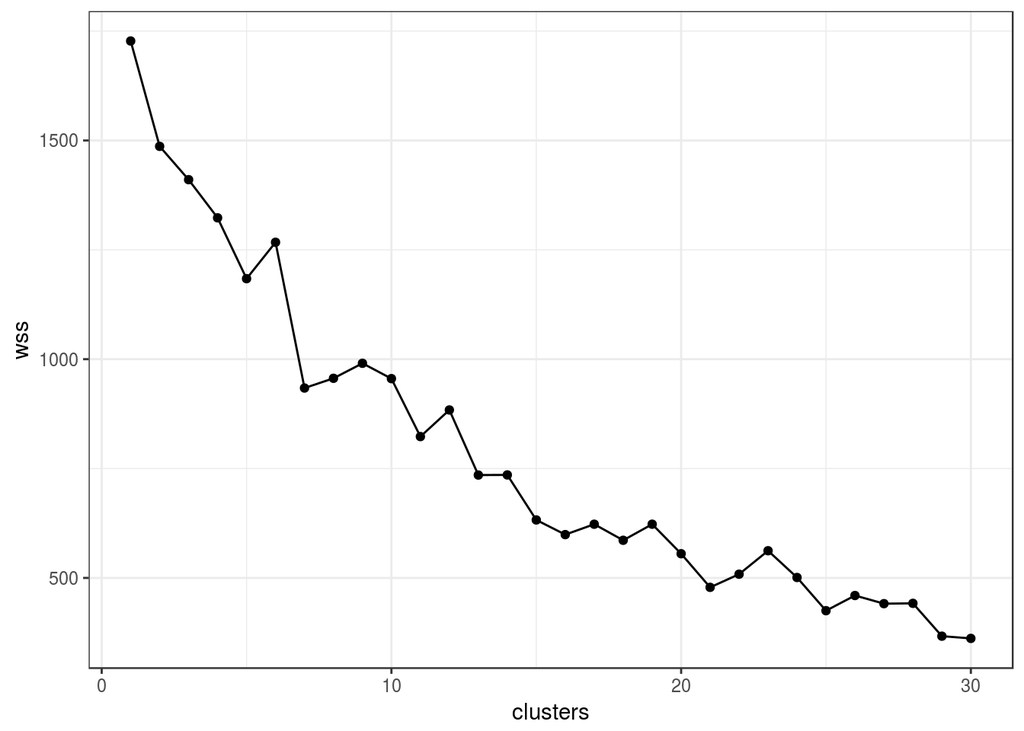

```r
### Load DAVID data and filter
roUp <- read.table("david_ro_up_1000_biological_process.txt", header = TRUE, sep = "\t", stringsAsFactors = FALSE)
roUp <- roUp[roUp$PValue < 0.001 | roUp$FDR < 0.05, c("Term", "PValue", "Genes", "Count")]
roDown <- read.table("david_ro_down_1000_biological_process.txt", header = TRUE, sep = "\t", stringsAsFactors = FALSE, quote = "")
roDown <- roDown[roDown$PValue < 0.001 | roDown$FDR < 0.05, c("Term", "PValue", "Genes", "Count")]

roUp <- roUp[!(roUp$Term %in% roDown$Term), ]
roDown <- roDown[!(roDown$Term %in% roUp$Term), ]

### Determine optimal cluster number
roUpMatrix <- simplifyGo(roUp)
determineClusterNumbers(roUpMatrix, 30)
```

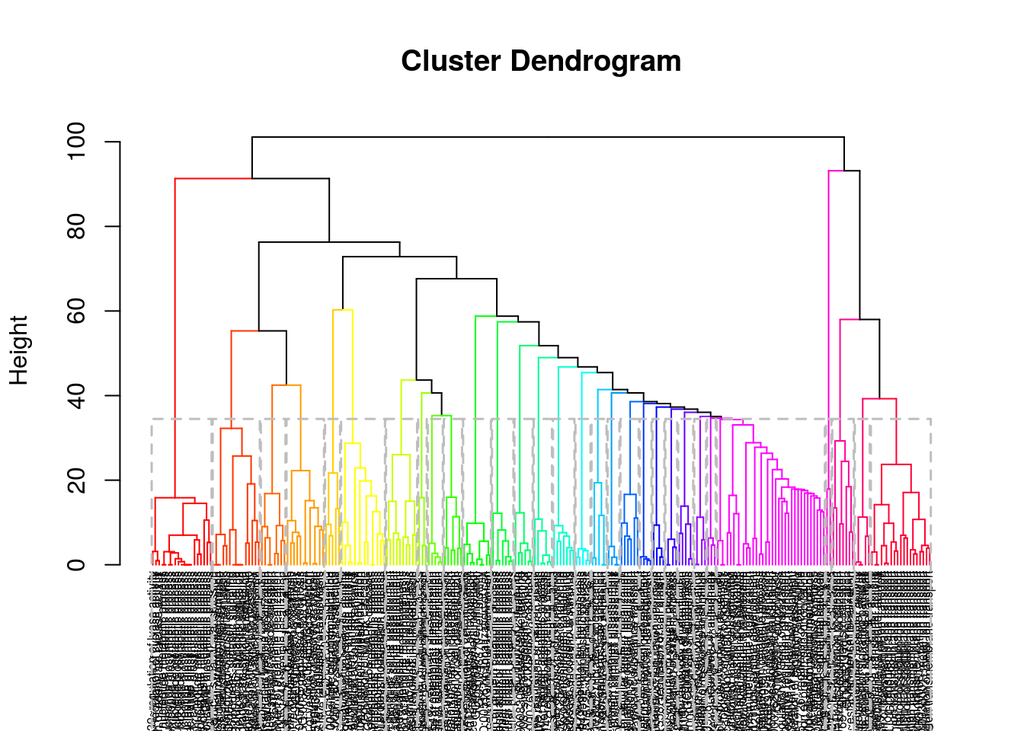

```r
### Create dendrogram and get clusters
roUpDendrogram <- hcut(roUpMatrix, k = 30, stand = TRUE)
fviz_dend(roUpDendrogram, rect = TRUE, cex = 0.5, show_labels = TRUE)
```

```r
roUpClusters <- getDendrogramClusters(roUpDendrogram)

### Merge clusters with original DAVID data
roUpClusters.mg <- merge(roUpClusters, roUp, "Term")[ ,c("Term", "PValue", "Count", "Cluster", "Order")]
roUpClusters.mg$NegLogPValue <- -log10(roUpClusters.mg$PValue)
roUpClusters.mg$Direction <- rep("Up", nrow(roUpClusters.mg))
roUpClusters.mg <- roUpClusters.mg[order(roUpClusters.mg$Order), ]

# write.csv to export file
```

Now, the dendrogram data is manually annotated and re-imported to R.

```r
roUpChart <- read.csv("roUpClusters_network_data.csv", header = TRUE, stringsAsFactors = FALSE)
```

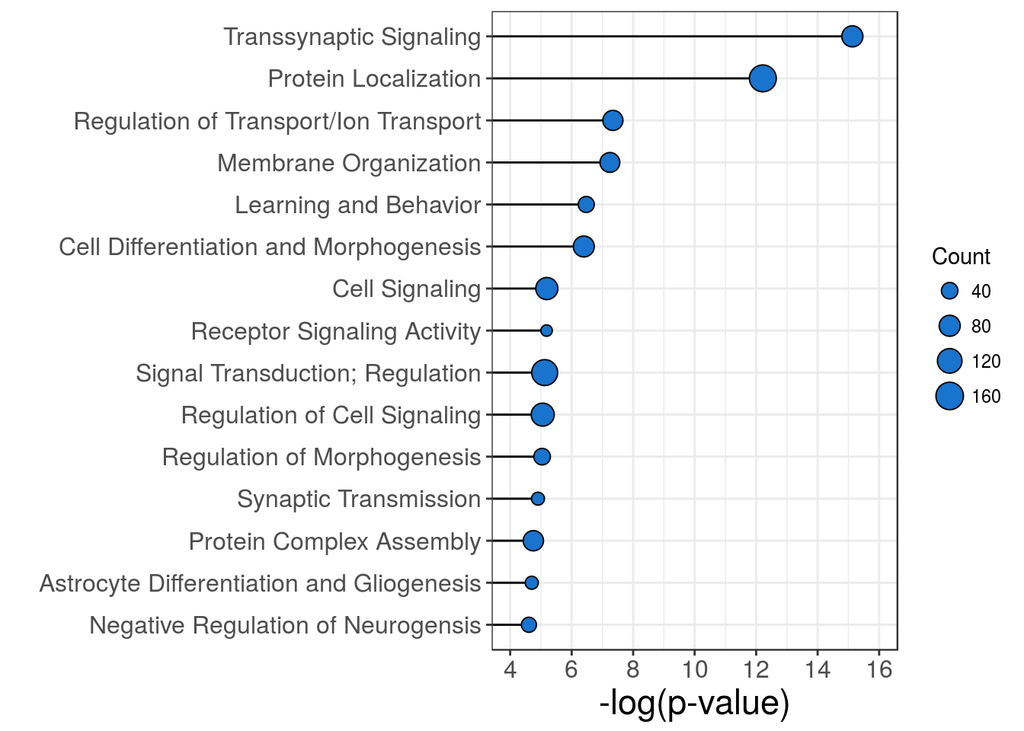

```r
### Create Ro Chart
roUpChart.s <- split(roUpChart, roUpChart$Category)
roUpSummary <- data.frame(Term = names(roUpChart.s),
                          NegLogPValue = lapply(roUpChart.s, function(x) mean(x$NegLogPValue)) %>% unlist() %>% unname(),
                          Count = lapply(roUpChart.s, function(x) mean(x$Count)) %>% unlist() %>% unname(),
                          stringsAsFactors = FALSE)
roUpSummary <- roUpSummary[roUpSummary$NegLogPValue > -log(0.01), ]
roUpSummary$Term <- factor(roUpSummary$Term, levels = roUpSummary[order(roUpSummary$NegLogPValue, decreasing = FALSE), "Term"])

ggplot(roUpSummary, aes(x = NegLogPValue, y = Term, size = Count)) +
  geom_segment(aes(yend = Term), xend = 0, color = "black", size = 0.5) +
  geom_point(shape = 21, color = "black", fill = "dodgerblue3") +
  scale_size_area(max_size = 5.5) +
  scale_size_continuous(limits = c(1, 160), breaks = c(40, 80, 120, 160)) +
  scale_x_continuous(limits = c(4, 16), breaks = seq(4, 16, by = 2)) +
  ylab("") +
  xlab("-log(p-value)") +
  theme_bw() +
  theme(axis.text.x = element_text(color = "grey30", size = 12),
        axis.text.y = element_text(color = "grey30", size = 12),
        axis.title.x = element_text(size = 17))
```

#### Ro+Rap top GO chart

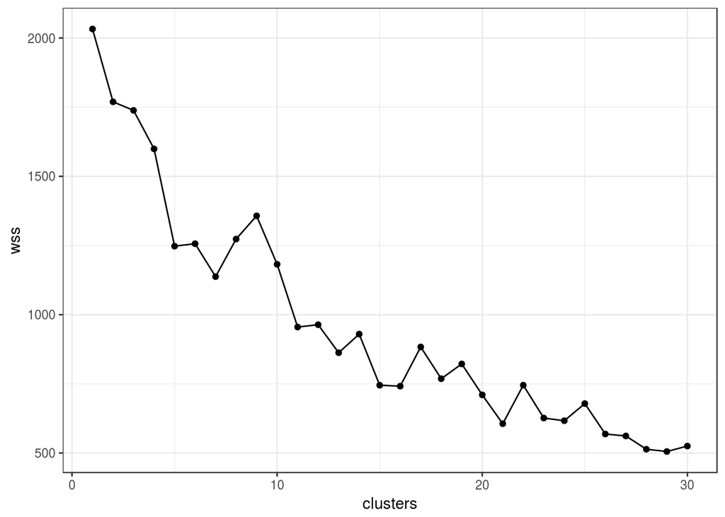

```r
### Load DAVID data and filter
roRapUp <- read.table("david_roRap_up_1000_biological_process.txt", header = TRUE, sep = "\t", stringsAsFactors = FALSE)
roRapUp <- roRapUp[roRapUp$PValue < 0.001 | roRapUp$FDR < 0.05, c("Term", "PValue", "Genes", "Count")]
roRapDown <- read.table("david_roRap_down_1000_biological_process.txt", header = TRUE, sep = "\t", stringsAsFactors = FALSE)
roRapDown <- roRapDown[roRapDown$PValue < 0.001 | roRapDown$FDR < 0.05, c("Term", "PValue", "Genes", "Count")]

roRapUp <- roRapUp[!(roRapUp$Term %in% roRapDown$Term), ]

### Determine optimal cluster number
roRapUpMatrix <- simplifyGo(roRapUp)
determineClusterNumbers(roRapUpMatrix, 30)
```

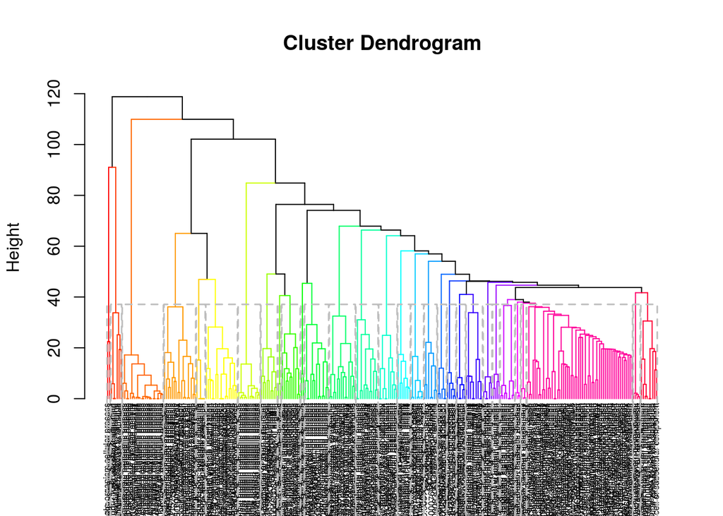

```r
### Create dendrogram and get clusters
roRapUpDendrogram <- hcut(roRapUpMatrix, k = 30, stand = TRUE)
fviz_dend(roRapUpDendrogram, rect = TRUE, cex = 0.5, show_labels = TRUE) # 803 x 469
```

```r
roRapUpClusters <- getDendrogramClusters(roRapUpDendrogram)

### Merge clusters with original DAVID data
roRapUpClusters.mg <- merge(roRapUpClusters, roRapUp, "Term")[ ,c("Term", "PValue", "Count", "Cluster", "Order")]
roRapUpClusters.mg$NegLogPValue <- -log10(roRapUpClusters.mg$PValue)
roRapUpClusters.mg$Direction <- rep("Up", nrow(roRapUpClusters.mg))
roRapUpClusters.mg <- roRapUpClusters.mg[order(roRapUpClusters.mg$Order), ]

# write.csv to export file
```

Now, the dendrogram data is manually annotated and re-imported to R.

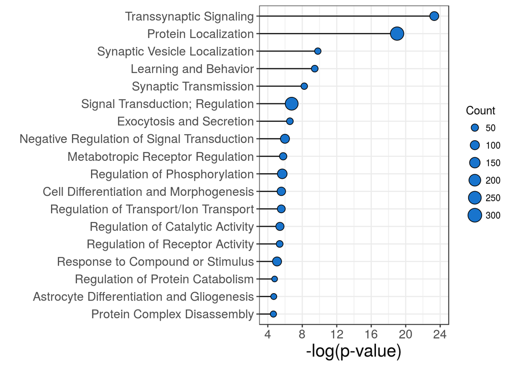

```r
### Create RoRap Chart
roRapUpChart <- read.csv("roRapUpClusters_network_data.csv", header = TRUE, stringsAsFactors = FALSE)
roRapUpChart.s <- split(roRapUpChart, roRapUpChart$Category)
roRapUpSummary <- data.frame(Term = names(roRapUpChart.s),
                          NegLogPValue = lapply(roRapUpChart.s, function(x) mean(x$NegLogPValue)) %>% unlist() %>% unname(),
                          Count = lapply(roRapUpChart.s, function(x) mean(x$Count)) %>% unlist() %>% unname(),
                          stringsAsFactors = FALSE)
roRapUpSummary <- roRapUpSummary[roRapUpSummary$NegLogPValue > -log(0.01), ]
roRapUpSummary$Term <- factor(roRapUpSummary$Term, levels = roRapUpSummary[order(roRapUpSummary$NegLogPValue, decreasing = FALSE), "Term"])

ggplot(roRapUpSummary, aes(x = NegLogPValue, y = Term, size = Count)) +
  geom_segment(aes(yend = Term), xend = 0, color = "black", size = 0.5) +
  geom_point(shape = 21, color = "black", fill = "dodgerblue3") +
  scale_size_area(max_size = 5.5) +
  scale_size_continuous(limits = c(1, 300), breaks = c(50, 100, 150, 200, 250, 300)) +
  scale_x_continuous(limits = c(4, 24), breaks = seq(4, 24, by = 4)) +
  ylab("") +
  xlab("-log(p-value)") +
  theme_bw() +
  theme(axis.text.x = element_text(color = "grey30", size = 12),
        axis.text.y = element_text(color = "grey30", size = 12),
        axis.title.x = element_text(size = 17))
```

#### Depression top GO chart

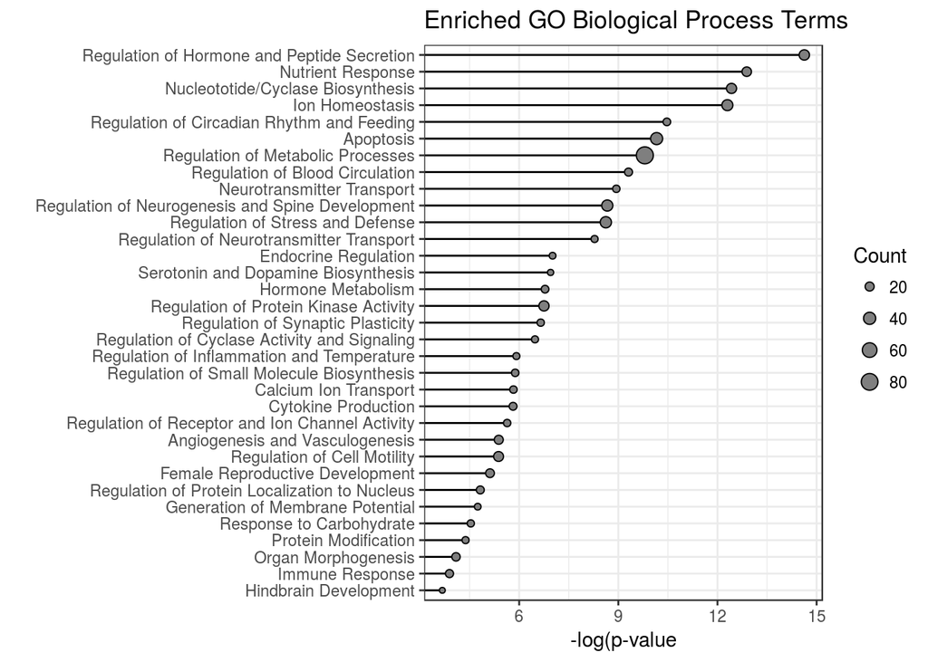

```r
depChart <- read.csv("depression_network_data.csv", header = TRUE, stringsAsFactors = FALSE)
depChart.s <- split(depChart, depChart$Category)
depChartSummary <- data.frame(Term = names(depChart.s),
                                NegLogPValue = lapply(depChart.s, function(x) mean(x$NegLogPValue)) %>% unlist() %>% unname(),
                                Count = lapply(depChart.s, function(x) mean(x$Count)) %>% unlist() %>% unname(),
                                stringsAsFactors = FALSE)

depChartSummary$Term <- factor(depChartSummary$Term, levels = depChartSummary[order(depChartSummary$NegLogPValue, decreasing = FALSE), "Term"])

ggplot(depChartSummary[-34, ], aes(x = NegLogPValue, y = Term, size = Count)) +
  geom_segment(aes(yend = Term), xend = 0, color = "black", size = 0.5) +
  geom_point(shape = 21, color = "black", fill = "grey50") +
  scale_size_area(max_size = 4) +
  ggtitle("Enriched GO Biological Process Terms") +
  ylab("") +
  xlab("-log(p-value") +
  theme_bw()
```

#### FMRP consensus top GO chart

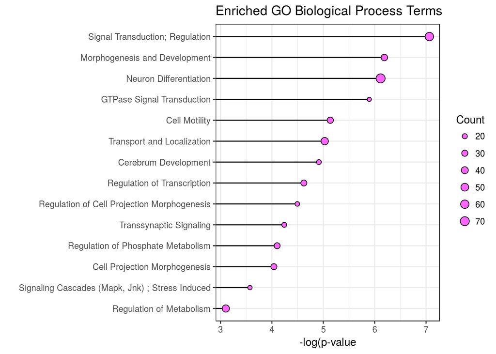

```r
bdChart <- read.csv("BD_network_data.csv", header = TRUE, stringsAsFactors = FALSE)
bdChart.s <- split(bdChart, bdChart$Category)
bdChartSummary <- data.frame(Term = names(bdChart.s),
                              NegLogPValue = lapply(bdChart.s, function(x) mean(x$NegLogPValue)) %>% unlist() %>% unname(),
                              Count = lapply(bdChart.s, function(x) mean(x$Count)) %>% unlist() %>% unname(),
                              stringsAsFactors = FALSE)

bdChartSummary$Term <- factor(bdChartSummary$Term, levels = bdChartSummary[order(bdChartSummary$NegLogPValue, decreasing = FALSE), "Term"])

ggplot(bdChartSummary, aes(x = NegLogPValue, y = Term, size = Count)) +
  geom_segment(aes(yend = Term), xend = 0, color = "black", size = 0.5) +
  geom_point(shape = 21, color = "black", fill = "#FF66FF") +
  scale_size_area(max_size = 4) +
  ggtitle("Enriched GO Biological Process Terms") +
  ylab("") +
  xlab("-log(p-value") +
  theme_bw()
```

### Univariate K-means clustering and GO ontology

#### Ro fold-changes

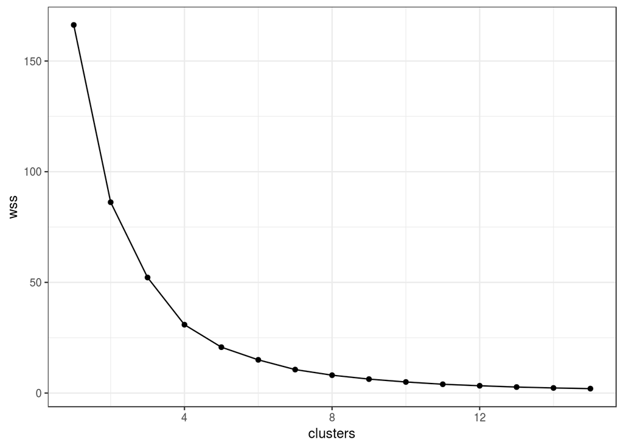

```r
determineClusterNumbers1D(fc$RO, 15)
```

```r
roClust <- Ckmeans.1d.dp(fc$RO, 8)
roClusters <- data.frame(row.names = row.names(fc),
                         foldChange = fc$RO,
                         cluster = roClust$cluster)   ### Gather clustering data

### Remove tails of distribution
roClusters <- roClusters[roClusters$foldChange < 1.5, ]
roClusters <- roClusters[roClusters$foldChange > -1.6, ]
```

For GO clustering, we took the genes from each cluster and sent them to DAVID. For example, in the first cluster we would use the following code:

```r
roClusters.s <- split(roClusters, roClusters$cluster)
functionalAnnotationChart(roClusters.s[[1]] %>% row.names(),
                          term = "GOTERM_BP_ALL",
                          filename = "DAVID_BP_KM1D_CLUST1.txt")
```

The GO clustering reveals that for 1-D clustering across the entire distribution by fold-change, the fifth cluster contains genes enriched for trans-synaptic signaling that change together (average p-value = $6.00 * 10^{-8}$).

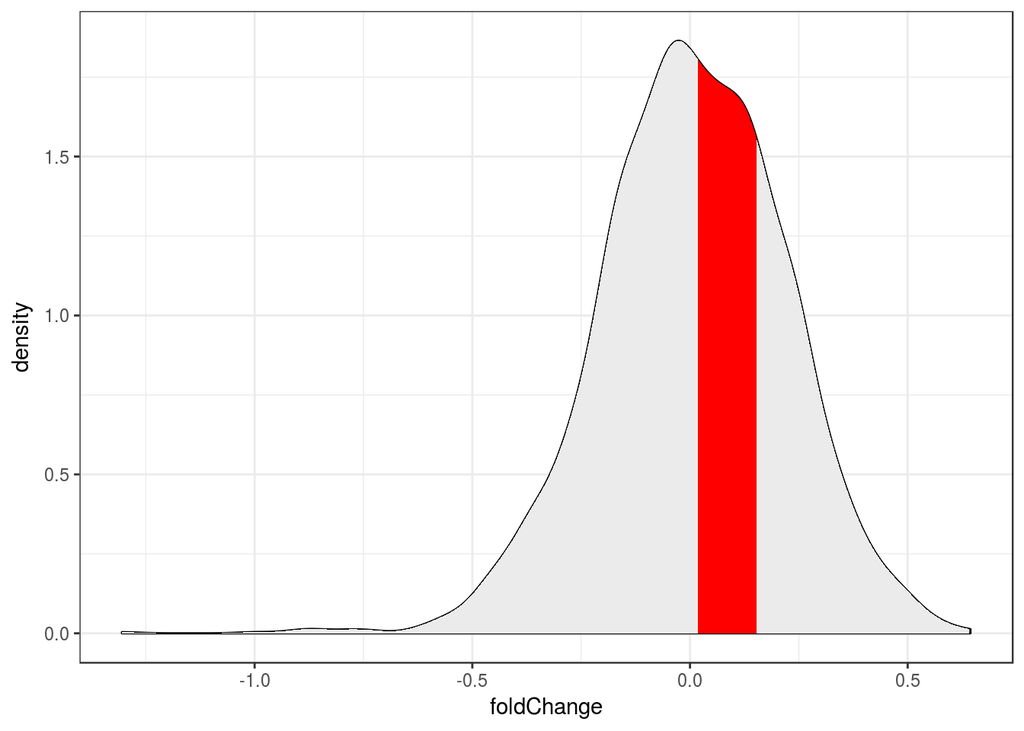

```r
### For loop to set boundaries of clusters within distribution during plotting
roBoundaries = NULL

for(i in 1:(roClusters$cluster %>% max())) {
  roBoundaries <- rbind(roBoundaries, split(roClusters, roClusters$cluster)[[i]]$foldChange %>% range())
}

### Plot data
p <-
  ggplot(roClusters, aes(x = foldChange)) +
    geom_density() +
    theme_bw()

d <- ggplot_build(p)$data[[1]]

p +
  geom_area(data = subset(d, x < roBoundaries[7,2]), aes(x = x, y = y), fill = "grey92") +
  geom_area(data = subset(d, x < roBoundaries[6,2]), aes(x = x, y = y), fill = "grey92") +
  geom_area(data = subset(d, x < roBoundaries[5,2]), aes(x = x, y = y), fill = "red") +
  geom_area(data = subset(d, x < roBoundaries[4,2]), aes(x = x, y = y), fill = "grey92") +
  geom_area(data = subset(d, x < roBoundaries[3,2]), aes(x = x, y = y), fill = "grey92") +
  geom_area(data = subset(d, x < roBoundaries[2,2]), aes(x = x, y = y), fill = "grey92") +
  geom_area(data = subset(d, x < roBoundaries[1,2]), aes(x = x, y = y), fill = "grey92")
```

#### Ro+Rap fold-changes

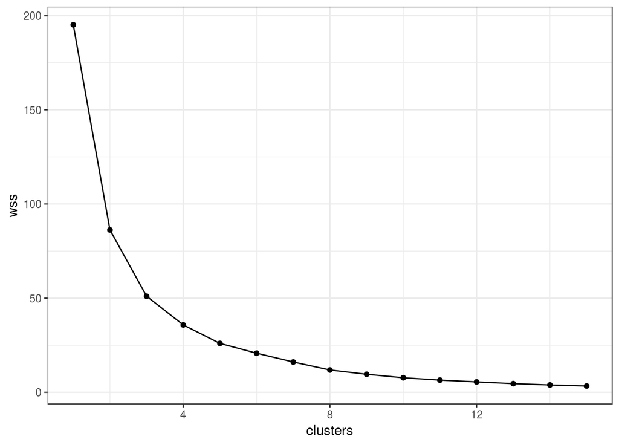

```r
determineClusterNumbers1D(fc$RO_RAP, 15)
```

```r
roRapClust <- Ckmeans.1d.dp(fc$RO_RAP, 8)
roRapClusters <- data.frame(row.names = row.names(fc),
                         foldChange = fc$RO_RAP,
                         cluster = roRapClust$cluster)   ### Gather clustering data

### Remove tails of distribution
roRapClusters <- roRapClusters[roRapClusters$foldChange < 1.5, ]
roRapClusters <- roRapClusters[roRapClusters$foldChange > -1.6, ]
```

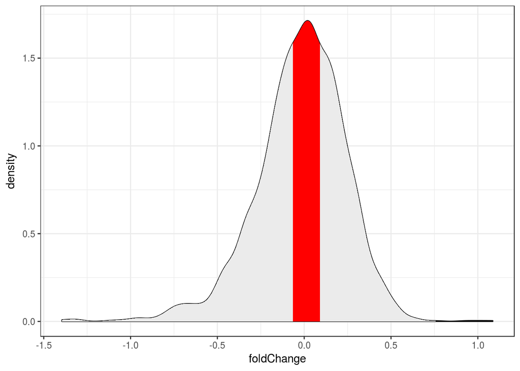

```r
### For loop to set boundaries of clusters within distribution during plotting
roRapBoundaries = NULL

for(i in 1:(roRapClusters$cluster %>% max())) {
  roRapBoundaries <- rbind(roRapBoundaries, split(roRapClusters, roRapClusters$cluster)[[i]]$foldChange %>% range())
}

### Plot data
p1 <-
  ggplot(roRapClusters, aes(x = foldChange)) +
    geom_density() +
    theme_bw()

d1 <- ggplot_build(p1)$data[[1]]

p1 +
  geom_area(data = subset(d1, x < roRapBoundaries[7,2]), aes(x = x, y = y), fill = "grey92") +
  geom_area(data = subset(d1, x < roRapBoundaries[6,2]), aes(x = x, y = y), fill = "grey92") +
  geom_area(data = subset(d1, x < roRapBoundaries[5,2]), aes(x = x, y = y), fill = "red") +
  geom_area(data = subset(d1, x < roRapBoundaries[4,2]), aes(x = x, y = y), fill = "grey92") +
  geom_area(data = subset(d1, x < roRapBoundaries[3,2]), aes(x = x, y = y), fill = "grey92") +
  geom_area(data = subset(d1, x < roRapBoundaries[2,2]), aes(x = x, y = y), fill = "grey92") +
  geom_area(data = subset(d1, x < roRapBoundaries[1,2]), aes(x = x, y = y), fill = "grey92")
```

### Fold-Change Correlation

The purpose of this plot is to see gene that changed in the same direction between the two calculated fold-change categories (Saline/Ro or Ro+Rap/Ro).

```r
### Load data for trans-synaptic genes so they can be uniquely colored on the plot.
transRo <- read.csv("roTranssynaptic.csv", stringsAsFactors = FALSE)
transRo[ ,1] <- NULL
transRoRap <- read.csv("roRapTranssynaptic.csv", stringsAsFactors = FALSE)
transRoRap[ ,1] <- NULL
trans <- c(transRo$genes, transRoRap$genes) %>% unique()
```

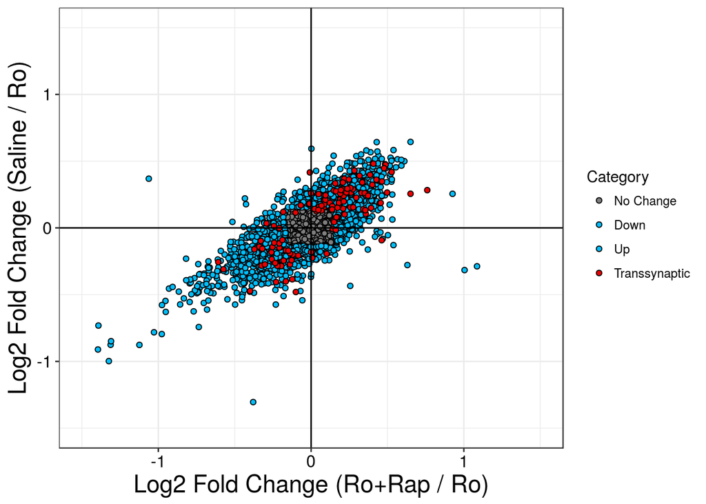

```r
fc$Category <- rep("No Change", nrow(fc))
fc[fc$RO > quantile(fc$RO, 0.75) | fc$RO_RAP > quantile(fc$RO_RAP, 0.75), "Category"] <- "Up"
fc[fc$RO < quantile(fc$RO, 0.25) | fc$RO_RAP < quantile(fc$RO_RAP, 0.25), "Category"] <- "Down"
fc[row.names(fc) %in% trans, "Category" ] <- "Transsynaptic"
plotOrder <- c("No Change", "Down", "Up", "Transsynaptic")
fc$Category <- reorder.factor(fc$Category, new.order = plotOrder)
fc <- fc %>% arrange(Category)

ggplot(fc, aes(x = RO_RAP, y = RO, color = Category, fill = Category)) +
  geom_point(shape = 21) +
  geom_hline(yintercept = 0) +
  geom_vline(xintercept = 0) +
  scale_x_continuous(limits = c(-1.5, 1.5)) +
  scale_y_continuous(limits = c(-1.5, 1.5)) +
  xlab("Log2 Fold Change (Ro+Rap / Ro)") +
  ylab("Log2 Fold Change (Saline / Ro)") +
  scale_fill_manual(values = c("grey50", "deepskyblue1", "deepskyblue1", "red2")) +
  scale_color_manual(values = c("black", "black", "black", "black")) +
  theme_bw() +
  theme(axis.text.x = element_text(color = "black", size = 12),
        axis.text.y = element_text(color = "black", size = 12),
        axis.title.x = element_text(size = 17),
        axis.title.y = element_text(size = 17))
```

### Bivariate K-means clustering and GO ontology

Finally, we will cluster the above genes using 2-D K-means. We will use the same approach as before by minimizing the WSS for clusters.

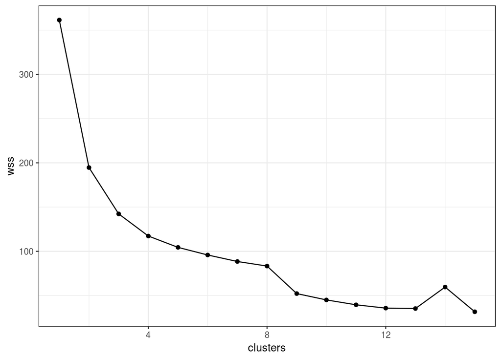

```r
### Load data and cluster
fc <- read.csv("finalData.csv", header = TRUE, stringsAsFactors = FALSE)
row.names(fc) <- fc$Row.names
fc[ ,1] <- NULL
fc <- fc[ ,c("logFC.x", "logFC.y")]
names(fc) <- c("RO", "RO_RAP")

determineClusterNumbers(fc, 15)
```

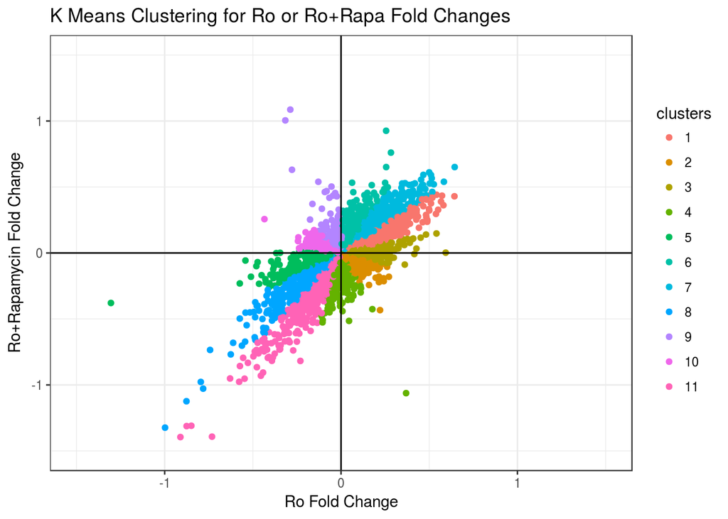

```r
kMeansPlot(fc, 11)
```

```r
### Extract clusters
clusterID <- data.frame(gene = row.names(fc),
                        cluster = as.integer(kMeansPlot(fc, 8)$data$clusters),
                        stringsAsFactors = FALSE)
clusterID <- split(clusterID, clusterID$cluster)

### Perform GO clustering as before
```

### References

[1] Merico D., Isserlin R, Stueker O, Emili A, Bader G.D. (2010). Enrichment map: a network-based method for gene-set enrichment visualization and interpretation. *PLoS One* 5(11), e13984.